# GWAS Report

## Overview

These are the GWAS results for job run_all with 337.475 samples, run for the phenotype Current .

## Methods

The association between Current and each variant with a minor allele count $\ge$ 30 and an imputation quality metric $r^2 \ge$ 0.8 was tested using the logistic regression model:

Current ~ marker + PC1 + PC2 + PC3 + PC4 + PC5 + PC6 + PC7 + PC8 + PC9 + PC10 + PC11 + PC12 + PC13 + PC14 + PC15 + PC16 + PC17 + PC18 + PC19 + PC20 + array + sex + age

The association tests were performed using *plink2/2.00-alpha-2-20190429*, including a total of 19.064.366 markers (after filtering). Markers having a Hardy-Weinberg equilibrium exact test p-value below 1.0e-6 were filtered out.  
861 significant markers have been found. The genomic inflation factor was $\lambda =$ 1.1111664.

## GWAS parameters

The plink2 program was run with the following parameters:

- Minor allele count cutoff: 30
- Minor allele frequency cutoff: 0.00
- Maximum variance inflation factor: 50
- Sample missing call rate cutoff: 0.1
- Variant missing call rate cutoff: 0.1
- Minimum imputation quality: 0.8
- Maximum imputation quality: 2.0
- Hardy-Weinberg exact test p-value threshold: 1.0e-6

## Filtered samples and variants

The table displays the number of samples/variants that have been removed due to different filters:

- **SGENO**: Samples removed due to missing genotype. Cutoff: 0.1
- **VGENO**: Variants removed due to missing genotype. Cutoff: 0.1
- **VHWE**: Variants removed after Hardy-Weinberg exact test. P-value cutoff: 1.0e-6
- **VFREQ**: Variants removed due to allele frequency threshold(s). Cutoffs: mac = 30 ; maf = 0.00
- **VIMP**: Variants removed due to imputation quality filter (MACH-R2). Cutoff: 0.8 - 2.0

| CHROM | SGENO | % | VGENO | % | VHWE | % | VFREQ | % | VIMP | % |
| --- | --- | --- | --- | --- | --- | --- | --- | --- | --- | --- |
| 1 | 0 | 0 | 41876 | 0.57 | 5231 | 0.071 | 3748870 | 51 | 2111513 | 29 |
| 2 | 0 | 0 | 36325 | 0.45 | 5060 | 0.062 | 4183838 | 51 | 2260475 | 28 |
| 3 | 0 | 0 | 28411 | 0.42 | 3524 | 0.053 | 3410951 | 51 | 1843977 | 28 |
| 4 | 0 | 0 | 32505 | 0.5 | 3677 | 0.056 | 3326349 | 51 | 1808723 | 28 |
| 5 | 0 | 0 | 24889 | 0.41 | 3724 | 0.061 | 3103370 | 51 | 1672957 | 28 |
| 6 | 0 | 0 | 32364 | 0.56 | 7096 | 0.12 | 2876768 | 50 | 1562232 | 27 |
| 7 | 0 | 0 | 29398 | 0.54 | 4574 | 0.085 | 2734232 | 51 | 1509193 | 28 |
| 8 | 0 | 0 | 21838 | 0.41 | 3720 | 0.07 | 2705353 | 51 | 1467844 | 28 |
| 9 | 0 | 0 | 23416 | 0.58 | 2980 | 0.073 | 2048187 | 50 | 1153895 | 28 |
| 10 | 0 | 0 | 23746 | 0.52 | 4113 | 0.09 | 2300280 | 50 | 1267117 | 28 |

[output cut: 13 more lines]

## Genome-wide significant markers

- Markers with $p \le 5 \cdot 10^{-8}$ are displayed, no matter what the corresponding $\beta$-value is.
- Spreadsheet with significant markers (only available if copied separately)
- ID: link to [Phenoscanner](http://www.phenoscanner.medschl.cam.ac.uk)
- POS: link to marker position at [UCSC Genome Brower](https://genome.ucsc.edu)
- genes: link to nearest gene (UCSC Genome Brower)
- Note : *A1_FREQ*, *BETA*, *SE*, and *P* are not available if only one significant marker resides on a whole chromosome.

## GCTA-COJO results

GCTA cojo was not conducted.

## CLUMP results

Plink clumping was not conducted.

## Unpruned significant markers

|  | ID | CHR | POS | OTHER | A1 | A1_FREQ | BETA | SE | P | genes |
| --- | --- | --- | --- | --- | --- | --- | --- | --- | --- | --- |
| 1 | rs3001723 | 1 | 44037685 | G | A | 0.3 | 0.05496 | 0.00883 | 4.78e-10 | LOC107984948 |
| 2 | rs11210887 | 1 | 44076019 | A | G | 0.3 | 0.0557 | 0.00884 | 2.91e-10 | KLF17 |
| 3 | rs549845 | 1 | 44076469 | A | G | 0.3 | 0.05565 | 0.00884 | 3.016e-10 | KLF17 |
| 4 | rs499257 | 1 | 44078384 | C | T | 0.325 | 0.05244 | 0.00866 | 1.376e-09 | KLF17 |
| 5 | rs603542 | 1 | 44079411 | C | T | 0.325 | 0.05268 | 0.00866 | 1.155e-09 | KLF17 |
| 6 | rs653953 | 1 | 44083015 | A | G | 0.325 | 0.05328 | 0.00865 | 7.291e-10 | KLF17 |
| 7 | rs1143702 | 1 | 44086831 | T | C | 0.325 | 0.05338 | 0.00865 | 6.693e-10 | KLF17 |
| 8 | rs34269157 | 1 | 44092542 | CA | C | 0.333 | 0.05242 | 0.00877 | 2.258e-09 | KLF17 |
| 9 | rs11429972 | 1 | 44096568 | ATT | A | 0.336 | 0.05414 | 0.00865 | 3.944e-10 | KLF17 |
| 10 | rs2970610 | 1 | 44097530 | C | T | 0.325 | 0.05248 | 0.00865 | 1.296e-09 | KLF17 |

[output cut: 851 more lines]

## QQ-plot for $p$-values

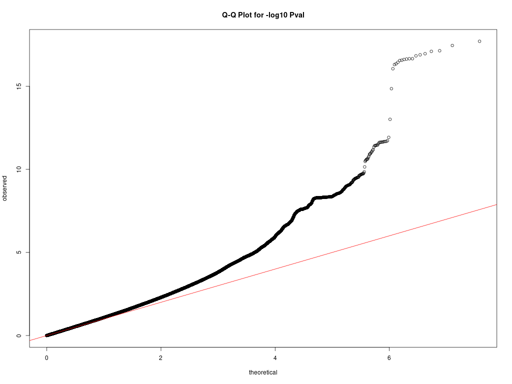

## Manhattan plot

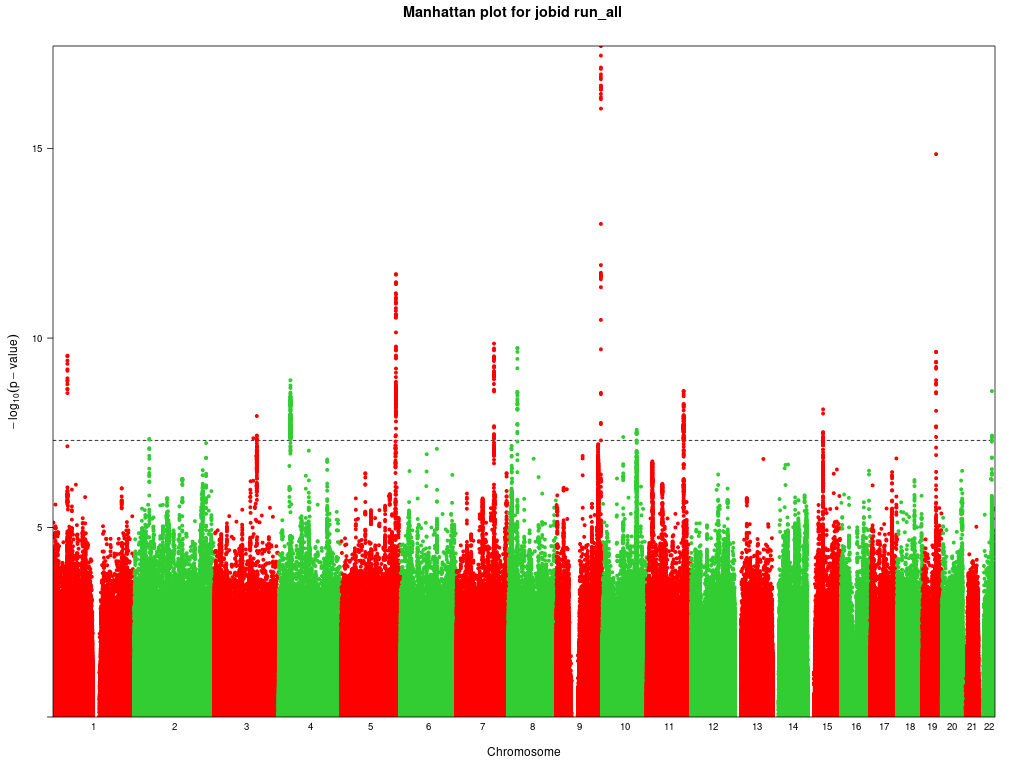

## SNP density plot

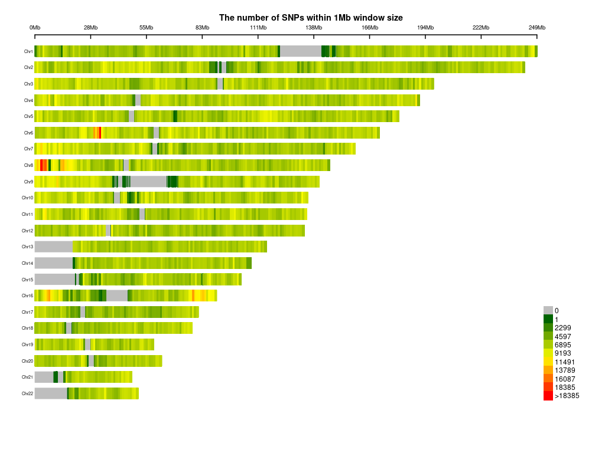

## Histogram of $\beta$ values

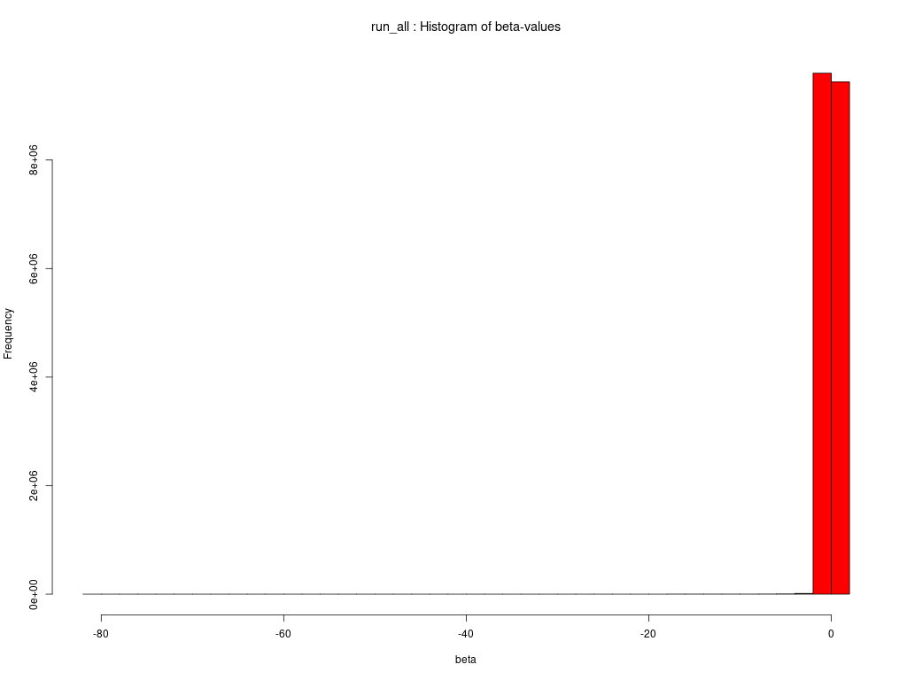

## Kernel density plot of $\beta$ values

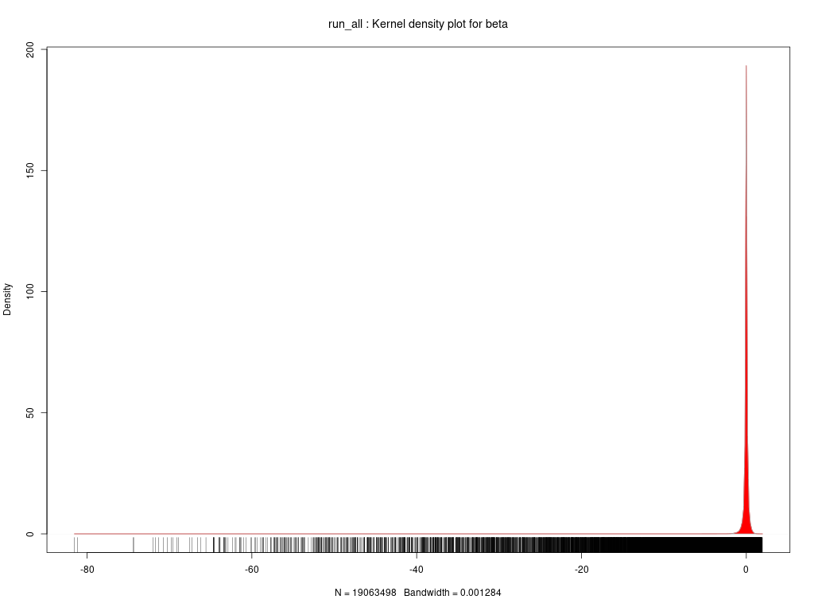

## Regression diagnostics

A regression was conducted using the linear model

Current ~ PC1 + PC2 + PC3 + PC4 + PC5 + PC6 + PC7 + PC8 + PC9 + PC10 + PC11 + PC12 + PC13 + PC14 + PC15 + PC16 + PC17 + PC18 + PC19 + PC20 + array + sex + age

(Note that no marker genotype has been included). The dataframe used as regression input is stored in *run_all_Current_regression_frame.RData*, while the residuals are in *run_all_Current_regression_resid.RData*.

### Regression coefficients obtained with `glm()`:

|  | Estimate | Std. Error | z value | Pr(>\|z\|) |
| --- | --- | --- | --- | --- |
| (Intercept) | 0.243 | 0.0643 | 3.78 | 0.00016 |
| PC1 | 0.00308 | 0.00378 | 0.814 | 0.415 |
| PC2 | -0.00284 | 0.00392 | -0.723 | 0.47 |
| PC3 | -0.0104 | 0.0038 | -2.74 | 0.00607 |
| PC4 | 0.00341 | 0.0029 | 1.18 | 0.239 |
| PC5 | 0.0185 | 0.00122 | 15.2 | 6.33e-52 |
| PC6 | 0.00406 | 0.00362 | 1.12 | 0.262 |
| PC7 | 0.00067 | 0.00325 | 0.206 | 0.837 |
| PC8 | 0.00714 | 0.00326 | 2.19 | 0.0282 |
| PC9 | 0.00468 | 0.00131 | 3.57 | 0.000355 |

[output cut: 14 more lines]

## Variance inflation factors

Variance inflation factors (VIF) are calculated in order to discover multicollinearity. VIF can be obtained by regressing a single independent variable against all other independent variables. As a rule of thumb, no variance inflation factor should be bigger than 10. Otherwise, highly correlated variables should be removed from the model.

|  | vif | rating |
| --- | --- | --- |
| PC1 | 1.1209 | ok |
| PC2 | 1.038 | ok |
| PC3 | 1.0869 | ok |
| PC4 | 2.32 | ok |
| PC5 | 2.2219 | ok |
| PC6 | 1.0708 | ok |
| PC7 | 1.1214 | ok |
| PC8 | 1.2718 | ok |
| PC9 | 1.1335 | ok |
| PC10 | 1.5309 | ok |

[output cut: 13 more lines]

## Technical information

- GWAS **workfolder** /castor/project/proj/GWAS_TEST/run_all
- **Parameter file**: /castor/project/proj/GWAS_TEST/run_all/run_all_gwas_params.txt